# Classification Case Study: The Titanic

Stephen W. Thomas

07 June, 2017

```r
library(tidyverse)
library(scales)
library(titanic)
library(rpart)
library(rpart.plot)
library(RColorBrewer)
library(MLmetrics)
```

# Introduction

On 11 April 1912, Mr. Patrick Dooley boarded the legendary Titanic passenger liner in Queenstown, Ireland, destined for a new life in New York City. Mr. Dooley was a 32 year old male, traveling without any family. He paid £7.75 for his ticket. What were the chances that Mr. Dooley would survive a catastrophic shipwreck?

The sinking of the Titanic is one of the most infamous shipwrecks in history. On 15 April 1912, during her maiden voyage from England to the New York City, the Titanic sank after colliding with an iceberg, killing 1,502 out of 2,224 passengers and crew. This sensational tragedy shocked the international community and led to better safety regulations for ships.

One of the reasons that the shipwreck led to such loss of life was that there were not enough lifeboats for the passengers and crew. Although there was some element of luck involved in surviving the sinking, some groups of people were more likely to survive than others, such as women, children, and the upper-class.

In this exercise, we will build analytics models to determine and quantify exactly which sorts of people were more likely to survive. In particular, we will construct a decision tree classifier model, and we will examine its output. This will (a) give us an understanding of which sorts of people were likely to survive, and (b) allow us to predict whether an individual, such as Mr. Patrick Dooley, would have survived.

## Learning Objectives

- Understand and interpret the results of a decision tree classifier model.
- Use a decision tree classifier model to predict new data instances.

# Loading the Data

The Titanic dataset is a popular and widely-used dataset in the analytics and machine learning circles. This dataset is based on the Titanic Passenger List edited by Michael A. Findlay, originally published in Eaton & Haas (1994) Titanic: Triumph and Tragedy, Patrick Stephens Ltd, and expanded with the help of the internet community. It contains data for 891 passengers.

```r
df <- titanic::titanic_train
str(df)
```

```
## 'data.frame':    891 obs. of  12 variables:
##  $ PassengerId: int  1 2 3 4 5 6 7 8 9 10 ...
##  $ Survived   : int  0 1 1 1 0 0 0 0 1 1 ...
##  $ Pclass     : int  3 1 3 1 3 3 1 3 3 2 ...
##  $ Name       : chr  "Braund, Mr. Owen Harris" "Cumings, Mrs. John Bradley (Florence Briggs Thayer)" "Heikkinen, Miss. Laina" "Futrelle, Mrs. Jacques Heath (Lily May Peel)" ...
##  $ Sex        : chr  "male" "female" "female" "female" ...
##  $ Age        : num  22 38 26 35 35 NA 54 2 27 14 ...
##  $ SibSp      : int  1 1 0 1 0 0 0 3 0 1 ...
##  $ Parch      : int  0 0 0 0 0 0 0 1 2 0 ...
##  $ Ticket     : chr  "A/5 21171" "PC 17599" "STON/O2. 3101282" "113803" ...
##  $ Fare       : num  7.25 71.28 7.92 53.1 8.05 ...
##  $ Cabin      : chr  "" "C85" "" "C123" ...
##  $ Embarked   : chr  "S" "C" "S" "S" ...
```

(Never mind the name of the following variable, “titanic_train.” There *is* another variable called titanic_test; however, there is no truth label in the titanic_test dataset, so it can’t really be used for testing. So, we use the “titantic_train” data set as the full dataset, and split it up into training and testing later.)

A good idea when performing any data analytics activity is to spend time looking at some of the raw data.

```r
head(df, n=20)
```

```
##    PassengerId Survived Pclass
## 1            1        0      3
## 2            2        1      1
## 3            3        1      3
## 4            4        1      1
## 5            5        0      3
## 6            6        0      3
## 7            7        0      1
## 8            8        0      3
## 9            9        1      3
## 10          10        1      2
## 11          11        1      3
## 12          12        1      1
## 13          13        0      3
## 14          14        0      3
```

[output cut: 48 more lines]

# Data Cleaning

Change some data types to be factor.

```r
df$Pclass = as.factor(df$Pclass)
df$Sex = as.factor(df$Sex)
df$Embarked = as.factor(df$Embarked)
```

Change the data type of the Survived variable to be binary.

```r
df$Survived = df$Survived==1
```

# Feature Engineering

In addition to the above variables in the dataset, we can create new variables to provide additional insight. (This process is called feature engineering.)

First, we can calculate whether a passenger was an adult or a child. We do so by checking whether the passenger’s age is greater than or less than 18, respectively.

```r
df$Child[df$Age < 18] <- 'Child'
df$Child[df$Age >= 18] <- 'Adult'
df$Child = as.factor(df$Child)
```

Next, we can calculate a passenger’s total family size by summing their siblings and spouses (sibsp) with their parents and children (parch).

```r
df$Fsize <- df$SibSp + df$Parch + 1
```

Next, we can examine the name variable to extract the passenger’s title, such as Mr., Mrs., etc.

```r
df$Title <- as.factor(gsub('(.*, )|(\\..*)', '', df$Name))
df$Title = as.factor(df$Title)
```

Next, we can calculate whether a passenger was a mother. We do so by checking if the passenger is female (sex), older than 18 (age), and has at least one child (parch).

```r
df$Mother <- 'Not Mother'
df$Mother[df$Sex == 'female' & df$Parch > 0 & df$Age > 18 & df$Title != 'Miss'] <- 'Mother'
df$Mother = as.factor(df$Mother)
```

Next, we can create a discretized version of Family Size, with levels “singleton,” “small”, and “large.”"

```r
df$FsizeD[df$Fsize == 1] <- 'singleton'
df$FsizeD[df$Fsize < 5 & df$Fsize > 1] <- 'small'
df$FsizeD[df$Fsize > 4] <- 'large'
```

We can extract the deck (i.e,. A - F) that the passenger was on.

```r
df$Deck<-factor(sapply(df$Cabin, function(x) strsplit(x, NULL)[[1]][1]))
```

# Another Data Sample

Now that we’ve cleaned the data and added some new variables, let’s look again.

```r
head(df, n=20)
```

```
##    PassengerId Survived Pclass
## 1            1    FALSE      3
## 2            2     TRUE      1
## 3            3     TRUE      3
## 4            4     TRUE      1
## 5            5    FALSE      3
## 6            6    FALSE      3
## 7            7    FALSE      1
## 8            8    FALSE      3
## 9            9     TRUE      3
## 10          10     TRUE      2
## 11          11     TRUE      3
## 12          12     TRUE      1
## 13          13    FALSE      3
## 14          14    FALSE      3
```

[output cut: 69 more lines]

```r
str(df)
```

```
## 'data.frame':    891 obs. of  18 variables:
##  $ PassengerId: int  1 2 3 4 5 6 7 8 9 10 ...
##  $ Survived   : logi  FALSE TRUE TRUE TRUE FALSE FALSE ...
##  $ Pclass     : Factor w/ 3 levels "1","2","3": 3 1 3 1 3 3 1 3 3 2 ...
##  $ Name       : chr  "Braund, Mr. Owen Harris" "Cumings, Mrs. John Bradley (Florence Briggs Thayer)" "Heikkinen, Miss. Laina" "Futrelle, Mrs. Jacques Heath (Lily May Peel)" ...
##  $ Sex        : Factor w/ 2 levels "female","male": 2 1 1 1 2 2 2 2 1 1 ...
##  $ Age        : num  22 38 26 35 35 NA 54 2 27 14 ...
##  $ SibSp      : int  1 1 0 1 0 0 0 3 0 1 ...
##  $ Parch      : int  0 0 0 0 0 0 0 1 2 0 ...
##  $ Ticket     : chr  "A/5 21171" "PC 17599" "STON/O2. 3101282" "113803" ...
##  $ Fare       : num  7.25 71.28 7.92 53.1 8.05 ...
##  $ Cabin      : chr  "" "C85" "" "C123" ...
##  $ Embarked   : Factor w/ 4 levels "","C","Q","S": 4 2 4 4 4 3 4 4 4 2 ...
##  $ Child      : Factor w/ 2 levels "Adult","Child": 1 1 1 1 1 NA 1 2 1 2 ...
##  $ Fsize      : num  2 2 1 2 1 1 1 5 3 2 ...
##  $ Title      : Factor w/ 17 levels "Capt","Col","Don",..: 12 13 9 13 12 12 12 8 13 13 ...
##  $ Mother     : Factor w/ 2 levels "Mother","Not Mother": 2 2 2 2 2 2 2 2 1 2 ...
##  $ FsizeD     : chr  "small" "small" "singleton" "small" ...
##  $ Deck       : Factor w/ 8 levels "A","B","C","D",..: NA 3 NA 3 NA NA 5 NA NA NA ...
```

# Descriptive Statistics

It’s always a good idea to get familiar with the data by understanding the variables. How many are there, what are their types, are there any special notes? Let’s do just that.

The dataset contains the following 12 variables for each passenger.

## Variable: pclass

Below is a cross tabulation for the variables pclass (rows) and survived (columns), along with sums of each row and column.

```r
addmargins(table(df$Pclass, df$Survived, dnn=c("Class", "Survive")))
```

```
##      Survive
## Class FALSE TRUE Sum
##   1      80  136 216
##   2      97   87 184
##   3     372  119 491
##   Sum   549  342 891
```

The tables shows us that, for example, there are a total of 216 passengers in class 1. Of those, 80 did not survive, while 136 did survive. Likewise, of those passengers that did survive, 136 of them came from class 1.

Below is a graphical representation of the same tabulation, color-coded by those who survived (blue, bottom) and those who did not (orange, top):

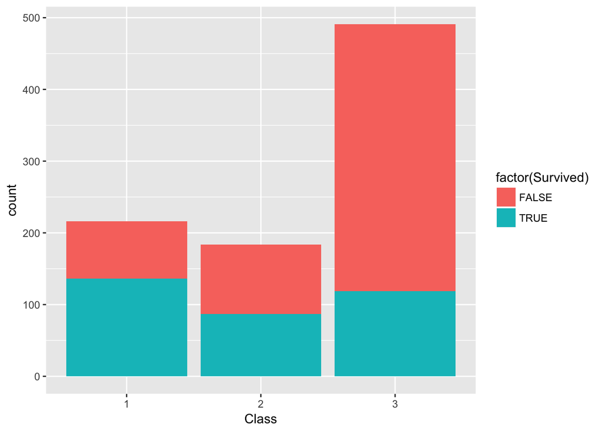

```r
qplot(Pclass, data=df, geom="bar", fill=factor(Survived), xlab="Class")
```

We see that most passengers are in class 3. However, those passengers in class 1 had a much higher survival rate.

## Variable: age

```r
df$age.cut = cut(df$Age, breaks=c(0, 7, 18, 40, 100))
addmargins(table(df$age.cut, df$Survived, dnn=c("Age", "Survive")))
```

```
##           Survive
## Age        FALSE TRUE Sum
##   (0,7]       16   34  50
##   (7,18]      53   36  89
##   (18,40]    260  165 425
##   (40,100]    95   55 150
##   Sum        424  290 714
```

Also, as age is continuous, let’s look at its summary statistics, such as minimum, maximum, etc.

```r
summary(df$Age)
```

```
##    Min. 1st Qu.  Median    Mean 3rd Qu.    Max.    NA's
##    0.42   20.12   28.00   29.70   38.00   80.00     177
```

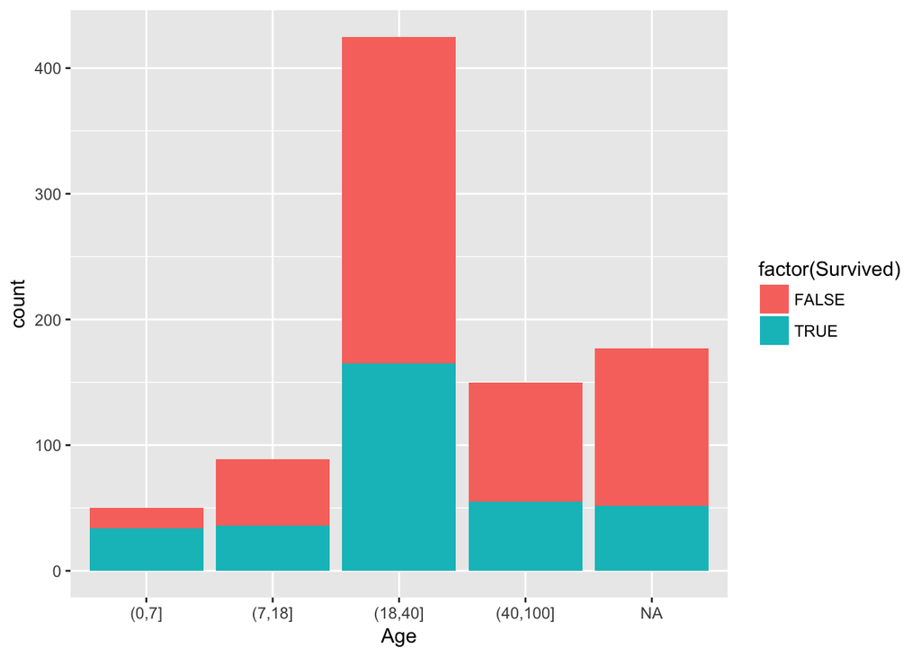

```r
qplot(age.cut, data=df, geom="bar", fill=factor(Survived), xlab="Age")
```

## Variable: sex

Now we turn to the sex of each passenger.

```r
addmargins(table(df$Sex, df$Survived, dnn=c("Sex", "Survive")))
```

```
##         Survive
## Sex      FALSE TRUE Sum
##   female    81  233 314
##   male     468  109 577
##   Sum      549  342 891
```

While there are more males aboard, females had a much better chance of survival.

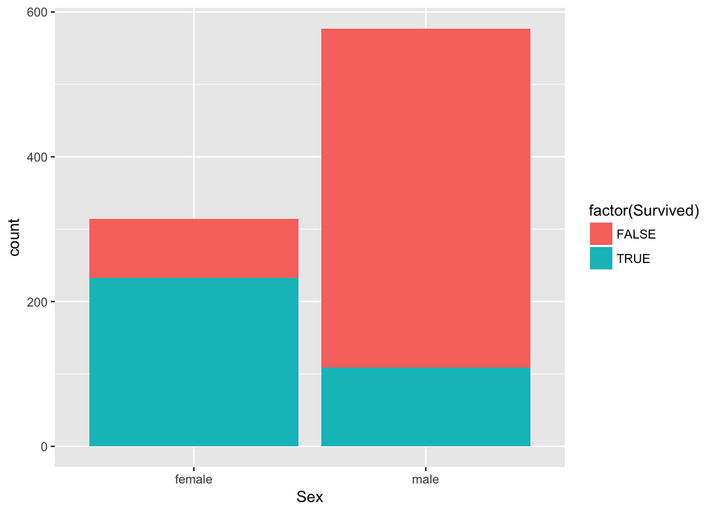

```r
qplot(Sex, data=df, geom="bar", fill=factor(Survived), xlab="Sex")
```

## Variable: fare

Now let’s look at ticket fare. Like age, it is a continuous variable, so we first bin the data into buckets.

```r
df$fare.cut = cut(df$Fare, breaks=c(0,  10, 20, 50, 100, 550), include.lowest=TRUE)
addmargins(table(df$fare.cut, df$Survived, dnn=c("Fare", "Survive")))
```

```
##            Survive
## Fare        FALSE TRUE Sum
##   [0,10]      269   67 336
##   (10,20]     103   76 179
##   (20,50]     126   90 216
##   (50,100]     37   70 107
##   (100,550]    14   39  53
##   Sum         549  342 891
```

```r
summary(df$Fare)
```

```
##    Min. 1st Qu.  Median    Mean 3rd Qu.    Max.
##    0.00    7.91   14.45   32.20   31.00  512.30
```

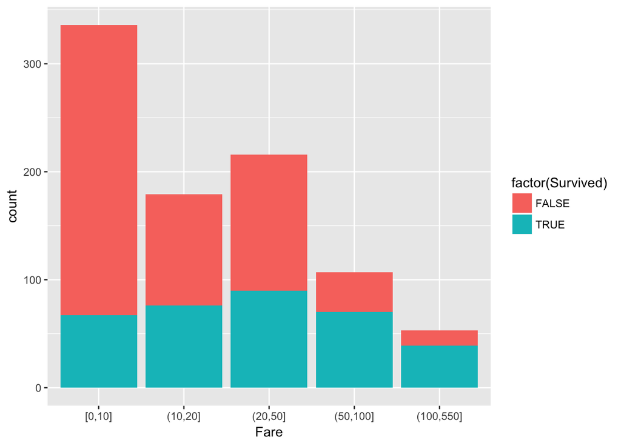

```r
qplot(fare.cut, data=df, geom="bar", fill=factor(Survived), xlab="Fare")
```

We see that most fares were below 15 pounds. (One fare was even 0 pounds. There’s probably an interesting story behind that!) However, there is a long tail: some tickets were 10-30 times as expensive, upwards of 500 pounds.

## Variable: embarked

From where did each passenger embark? As a historical sidenote, the Titanic departed from Southampton, England on 3 April 1912; Cherbourg, France on 10 April 1912; and Queenstown, Ireland on 11 April 1912.

```r
addmargins(table(df$Embarked, df$Survived, dnn=c("Embarked", "Survive")))
```

```
##         Survive
## Embarked FALSE TRUE Sum
##              0    2   2
##      C      75   93 168
##      Q      47   30  77
##      S     427  217 644
##      Sum   549  342 891
```

Most passengers boarded in Southampton. However, those that boarded in Cherbourg had the best chance of survival.

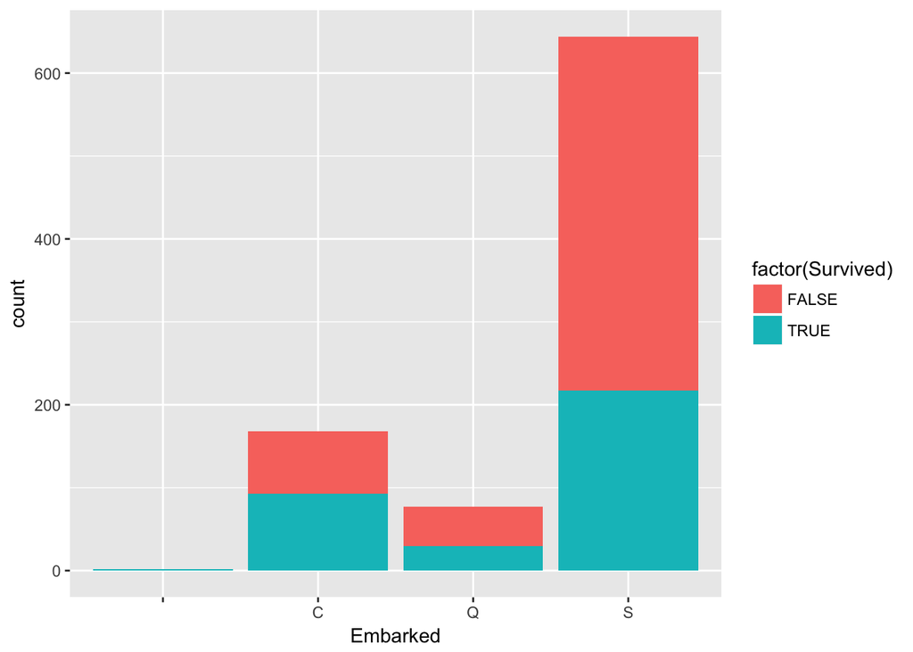

```r
qplot(Embarked, data=df, geom="bar", fill=factor(Survived), xlab="Embarked")
```

### Variable: title

```r
addmargins(table(df$Title, df$Survived, dnn=c("Title", "Survive")))
```

```
##               Survive
## Title          FALSE TRUE Sum
##   Capt             1    0   1
##   Col              1    1   2
##   Don              1    0   1
##   Dr               4    3   7
##   Jonkheer         1    0   1
##   Lady             0    1   1
##   Major            1    1   2
##   Master          17   23  40
##   Miss            55  127 182
##   Mlle             0    2   2
##   Mme              0    1   1
##   Mr             436   81 517
##   Mrs             26   99 125
##   Ms               0    1   1
##   Rev              6    0   6
##   Sir              0    1   1
##   the Countess     0    1   1
##   Sum            549  342 891
```

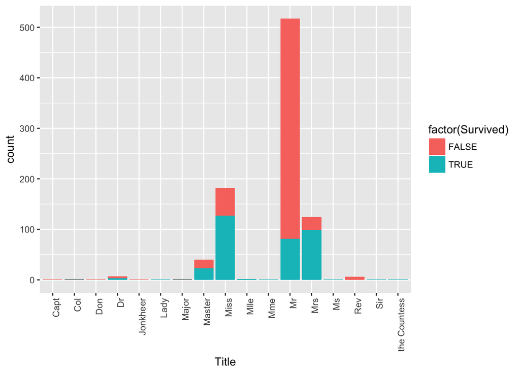

```r
qplot(Title, data=df, geom="bar", fill=factor(Survived), xlab="Title")+
  theme(axis.text.x = element_text(angle = 90, hjust = 1))
```

## Variable: family size

Family size is one of our engineered variables. Values of one indicate that the passenger was traveling alone.

```r
addmargins(table(df$Fsize, df$Survived, dnn=c("Family Size", "Survive")))
```

```
##            Survive
## Family Size FALSE TRUE Sum
##         1     374  163 537
##         2      72   89 161
##         3      43   59 102
##         4       8   21  29
##         5      12    3  15
##         6      19    3  22
##         7       8    4  12
##         8       6    0   6
##         11      7    0   7
##         Sum   549  342 891
```

We see that most passengers were singletons. This is due to the large number of third class passengers. Many third class passengers travelled alone, or some with friends, which is not under the umbrella of the sibsp definition. Also, many third class passengers were immigrating to the US. While they were married, they did not have their spouse aboard ship with them. They were sent off alone to establish a foothold and then later send for their spouses.

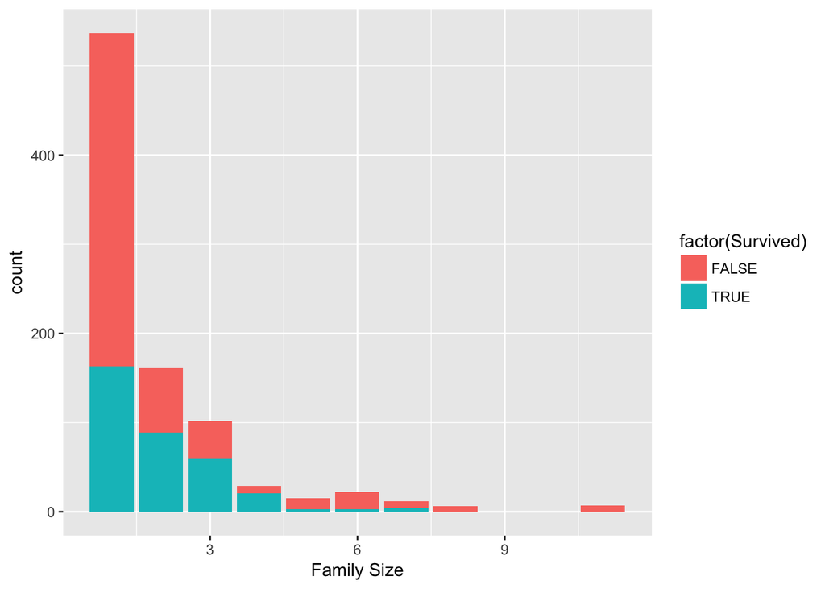

```r
qplot(Fsize, data=df, geom="bar", fill=factor(Survived), xlab="Family Size")
```

## Variable: mother

```r
addmargins(table(df$Mother, df$Survived, dnn=c("Mother", "Survive")))
```

```
##             Survive
## Mother       FALSE TRUE Sum
##   Mother        15   37  52
##   Not Mother   534  305 839
##   Sum          549  342 891
```

We see that most passengers were not mothers (according to our definition, at least), but mothers did survive more often.

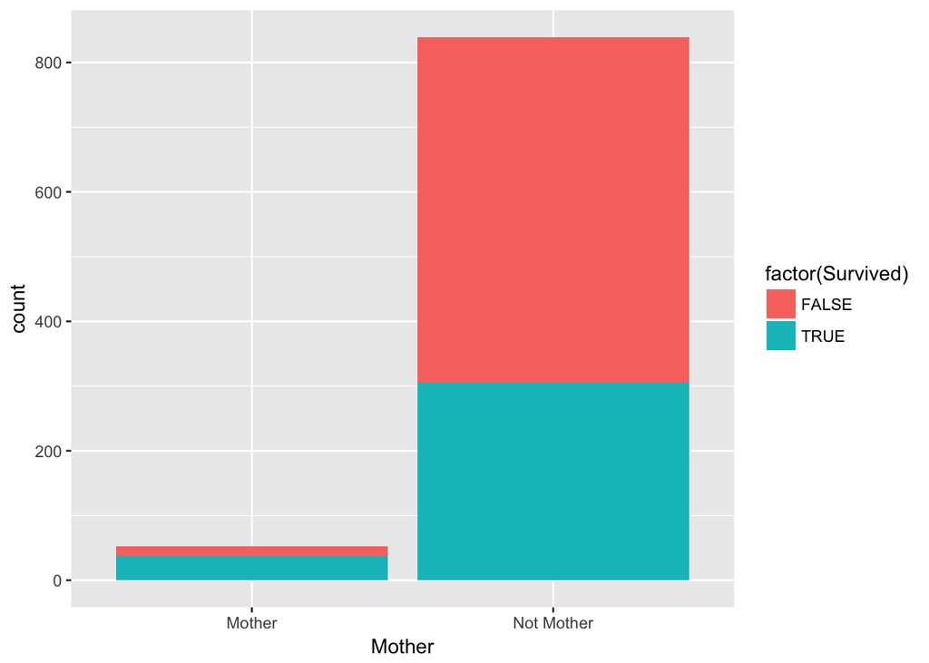

```r
qplot(Mother, data=df, geom="bar", fill=factor(Survived), xlab="Mother")
```

## Variable: child

```r
addmargins(table(df$Child, df$Survived, dnn=c("Child", "Survive")))
```

```
##        Survive
## Child   FALSE TRUE Sum
##   Adult   372  229 601
##   Child    52   61 113
##   Sum     424  290 714
```

We see that most passengers were adults. However, children had a better survival rate.

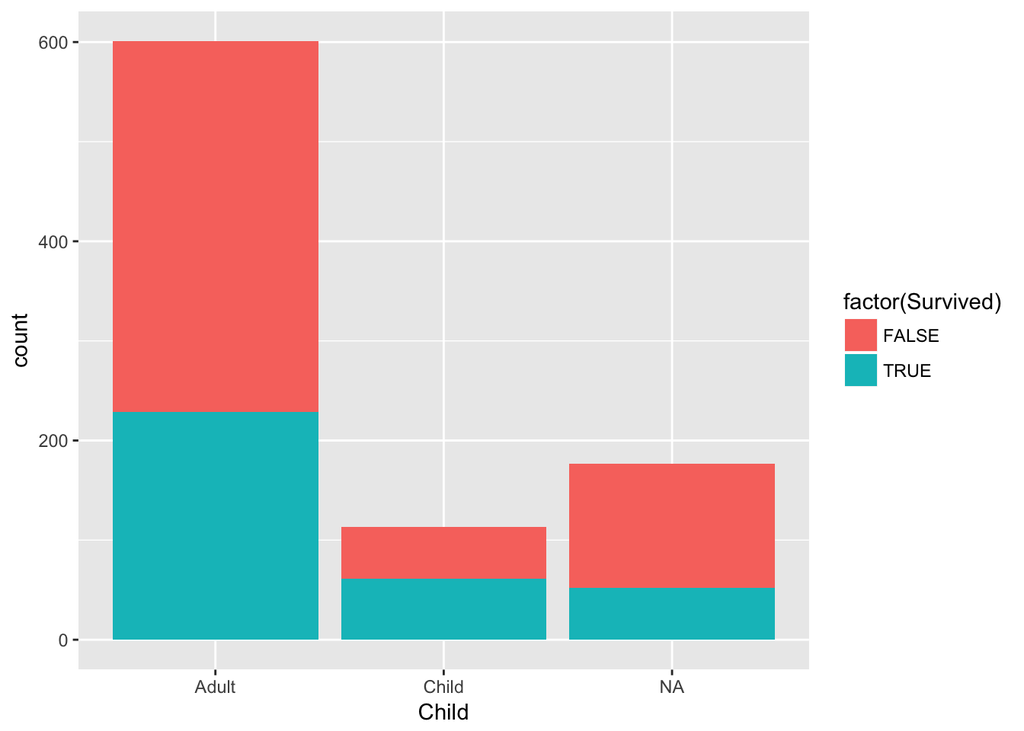

```r
qplot(Child, data=df, geom="bar", fill=factor(Survived), xlab="Child")
```

## Variable: survived

Finally, let’s examine the survived variable. The tabulation below is overkill, but it’s useful to look at it for verification.

```r
addmargins(table(df$Survived, df$Survived, dnn=c("Survived", "Survive")))
```

```
##         Survive
## Survived FALSE TRUE Sum
##    FALSE   549    0 549
##    TRUE      0  342 342
##    Sum     549  342 891
```

We see that most passengers unfortunately did not survive.

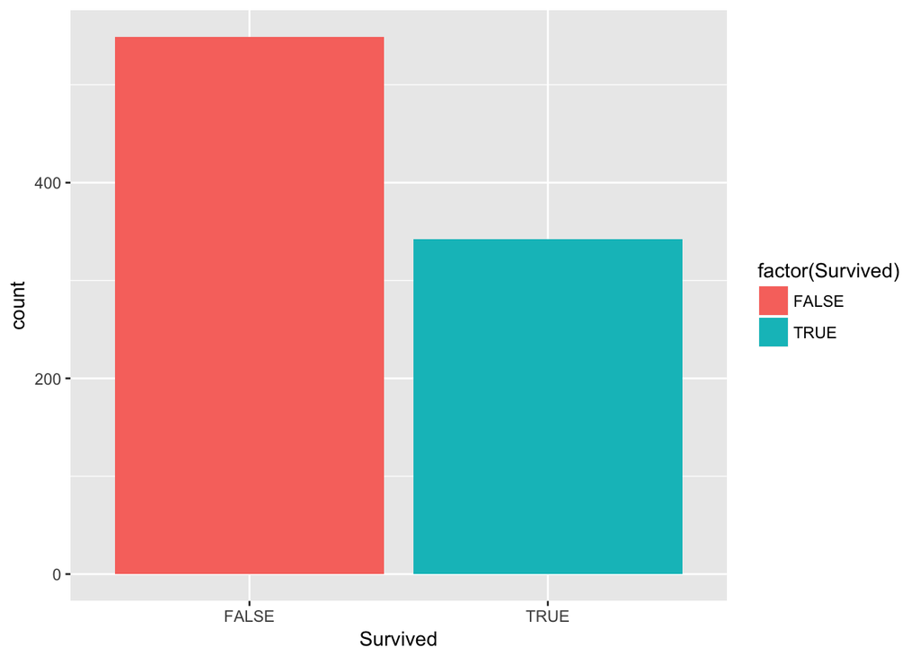

```r
qplot(Survived, data=df, geom="bar", fill=factor(Survived), xlab="Survived")
```

# Building a Classifier Model

Now that we have explored the data, it’s time to dive deeper. Which variable(s) are the biggest predictors of survival? Is it age, pclass, mother? All three variables seem to play a role, but we don’t yet know which are the most important. This is where classifier models shine. They can tell us exactly how all the variables relate to each other, and which are most important.

A decision tree is a popular classifier model in analytics. Here, the decision tree is automatically created by a machine learning algorithm as it learns simple decision rules from the data. These automatically-learned rules can then be used to both understand the variables and to predict future data. A big advantage of decision trees over other classifier models is that they are relatively simple for humans to understand and interpret.

A decision tree consists of nodes. Each node splits the data according to a rule. A rule is based on a variable in the data. For example, a rule might be “Age greater than 30.” In this case, the node splits the data by the age variable; those passengers that satisfy the rule (i.e., are greater than 30) follow the left path out of the node; the rest follow the right path out of the node. In this way, paths from the root node down to leaf nodes are created, describing the fate of certain types of passengers.

A decision tree path always starts with a root node (node number 1), which contains the most important splitting rule. Each subsequent node contains the next most important rule. After the decision tree is automatically created by the machine learning algorithm, one can use the decision tree to classify an individual by simply following a path: start at the root node and apply each rule to follow the appropriate path until you hit an end.

When creating a decision tree from data, the analyst can specify the number of nodes for the machine learning algorithm to create. More nodes leads to a more accurate model, at the cost of a more complicated and harder-to-interpret model. Likewise, fewer nodes usually leads to a less accurate model, but the model is easier to understand and interpret.

First thing’s first, let’s split the data into training and testing.

```r
set.seed(123)
train <- sample_frac(df, 0.8)
test <- setdiff(df, train)
```

```r
form = as.formula(Survived ~ Pclass + Sex + Age + Fare + Embarked + Fsize + Child + Mother)
tree <- rpart(form, train, method="class")
```

The textual rendering contains the node number, the rule, the number of rows that matched this rule, the deviance of this rule, and finally, the probability of survival at this node.

```r
tree
```

```
## n= 713
##
## node), split, n, loss, yval, (yprob)
##       * denotes terminal node
##
##   1) root 713 280 FALSE (0.6072931 0.3927069)
##     2) Sex=male 455  87 FALSE (0.8087912 0.1912088) *
##     3) Sex=female 258  65 TRUE (0.2519380 0.7480620)
##       6) Pclass=3 119  56 TRUE (0.4705882 0.5294118)
##        12) Embarked=S 73  29 FALSE (0.6027397 0.3972603)
##          24) Fare>=22.7375 18   2 FALSE (0.8888889 0.1111111) *
##          25) Fare< 22.7375 55  27 FALSE (0.5090909 0.4909091)
##            50) Fare< 10.825 34  13 FALSE (0.6176471 0.3823529)
##             100) Age>=19.5 27   8 FALSE (0.7037037 0.2962963) *
##             101) Age< 19.5 7   2 TRUE (0.2857143 0.7142857) *
##            51) Fare>=10.825 21   7 TRUE (0.3333333 0.6666667) *
##        13) Embarked=C,Q 46  12 TRUE (0.2608696 0.7391304) *
##       7) Pclass=1,2 139   9 TRUE (0.0647482 0.9352518) *
```

```r
printcp(tree)
```

```
##
## Classification tree:
## rpart(formula = form, data = train, method = "class")
##
## Variables actually used in tree construction:
## [1] Age      Embarked Fare     Pclass   Sex
##
## Root node error: 280/713 = 0.39271
##
## n= 713
##
##         CP nsplit rel error  xerror     xstd
## 1 0.457143      0   1.00000 1.00000 0.046571
## 2 0.026786      1   0.54286 0.54286 0.039057
## 3 0.012500      3   0.48929 0.51071 0.038186
## 4 0.010714      5   0.46429 0.48929 0.037572
## 5 0.010000      6   0.45357 0.50000 0.037882
```

Let’s look at a graphical rendering of the decision tree.

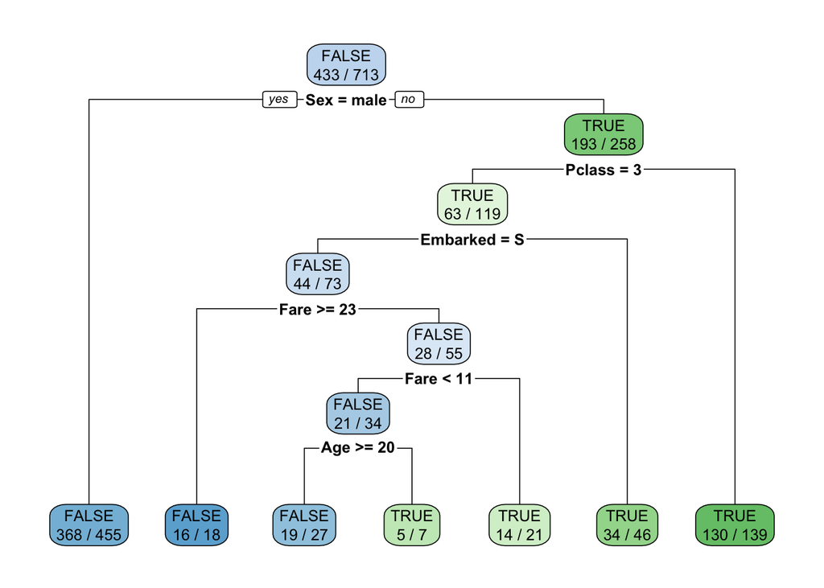

```r
rpart.plot(tree, extra=2)
```

Let’s use the classifier to predict the class of the testing data.

```r
predicted = predict(tree, test, type="class")
```

Let’s look at the confusion matrix.

```r
actual = test$Survived
table(actual, predicted)
```

```
##        predicted
## actual  FALSE TRUE
##   FALSE   107    9
##   TRUE     24   38
```

Let’s check the accuracy and other metrics of the classifier on the testing data.

```r
print(sprintf("Accuracy:    %.3f", Accuracy(y_true=actual, y_pred=predicted)))
```

```
## [1] "Accuracy:    0.815"
```

```r
print(sprintf("AUC:         %.3f", AUC(y_true=actual, y_pred=predicted)))
```

```
## [1] "AUC:         0.768"
```

```r
print(sprintf("Precision:   %.3f", Precision(y_true=actual, y_pred=predicted)))
```

```
## [1] "Precision:   0.817"
```

```r
print(sprintf("Recall:      %.3f", Recall(y_true=actual, y_pred=predicted)))
```

```
## [1] "Recall:      0.922"
```

```r
print(sprintf("F1 Score:    %.3f", F1_Score(predicted, actual)))
```

```
## [1] "F1 Score:    0.866"
```

```r
print(sprintf("Sensitivity: %.3f", Sensitivity(y_true=actual, y_pred=predicted)))
```

```
## [1] "Sensitivity: 0.922"
```

```r
print(sprintf("Specificity: %.3f", Specificity(y_true=predicted, y_pred=actual)))
```

```
## [1] "Specificity: 0.809"
```

# The Challenge

Now, see if you (yes, you!) can improve those metrics. Some ideas:

- Perform additional data cleaning
- Perform additional feature engineering
- Try different parameters for the rpart decision tree (see rpart’s help for more details)
- Try different packages for decisions trees (e.g., party, caret)
- Try different classifier algorithms (Naive Bayes, SVM, NN, …)
- Try ensemble methods: Random Forests, bagging, boosting

```r
# TODO: Insert your magic here!
```

# Questions

# Appendix A: Frequently Asked Questions

#### For those over age 25, the mean number of spouses/siblings is about 0.34. This seems a little low, does it not?

One possible explanation is the overwhelming “Third Class Bias,” as it is called. Many third class passengers travelled alone, or some with friends, which is not under the umbrella of the sibsp definition. Also, many third classers were immigrating to the US. They were married, but were sent off alone to establish a foothold and then later sent for their spouses.

#### For those under age 14 the mean number parents/children is 1.37. This seems a bit low.

Not all children travelled with their parents, especially in third class. Some children travelled with older siblings, nannies, aunts/uncles, etc. Actually, more often than not, children travelled with only one parent. After further investigation. Here are a few unusual passenger cases that came up:

- Case #1: Emanuel, Miss. Virginia Ethel. 3d Class. Age 5. sibsp/parch=0/0
  - Boarded with her nurse Miss. Elizabeth Dowdell. Escorted her to grandparents’ home in New York, NY.
- Case #2: Hassan, Mr. Houssein G N. 3d Class. Age 11. s/p=0/0
  - Traveled with family friend Mr. Nassef Cassem Albimona. Going to visit his parents in America from Lebanon. (Interesting note: Albimona was from Fredericksburg, VA)
- Case #3: Ayoub, Miss. Banoura. 3d Class. Age 13. s/p=0/0
  - Boarded with 5 cousins. Travelling to Detroit, MI to be reunited with family.
- Case #4: Nasser, Mrs. Nicholas Nasser. 2nd Class. Age 14. s/p=1/0
  - Married to a 32 year old man… sibsp stands for spouse rather than sibling… unusual at such a young age. She lied when she boarded the Titanic and claimed she was 18. However, her birth certificate proves that on April 15, 1912 she was 14, not 18!